# 통계학실험(009)과제9

박현 2019-14593

2019년 5월 29일

### 예제1. (handspan.txt)

다음은 167명의 학생들에 대해 성별(Sex)과 신장(Height) 그리고 손 한뼘의 길이(HandSpan)를 측정한 자료이다.

1. 신장과 손 한뼘의 길이는 서로 상관관계가 존재하는가? 표본 상관계수를 구하고 두 변수 의 산점도를 그려보자. 두 변수 사이에 선형적 연관성이 존재하는가?

```
## [1] 0.7395375
```

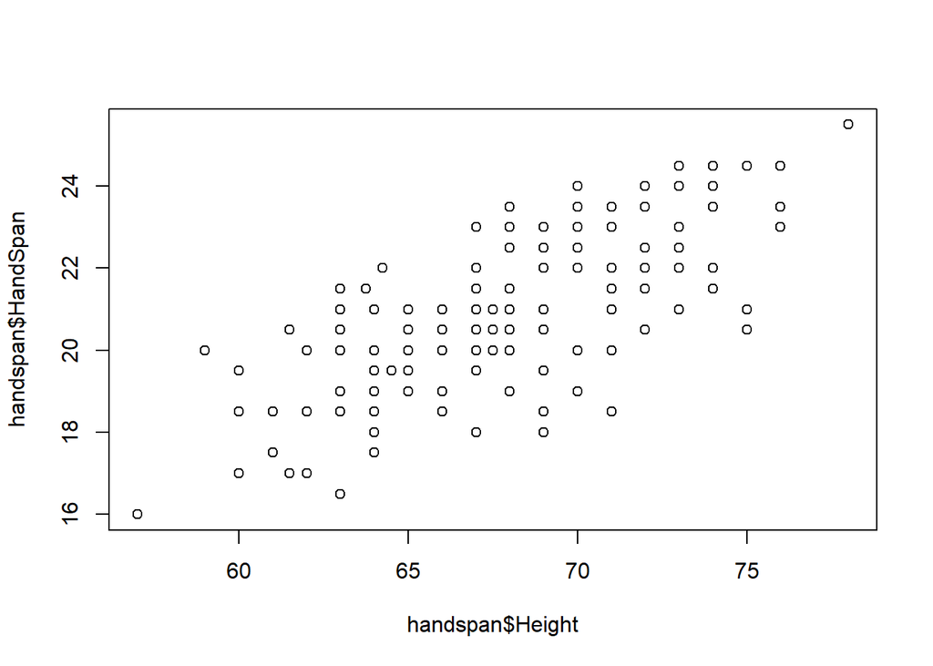

```r
handspan = read.table('handspan.txt',header=TRUE)
cor(handspan$Height, handspan$HandSpan) ; plot(handspan$Height, handspan$HandSpan)
```

산점도 상으로 두 변수 간에는 어느 정도 선형적 연관성이 있음을 확인할 수 있고 실제로 상 관계수를 구해보면 0.7395375로 나타난다.

2. 신장과 손 한뼘의 길이사이에 상관관계가 존재하는지 유의수준 5%에서 검정하여라.

```r
cor.test(handspan$Height, handspan$HandSpan)
```

```
##
##  Pearson's product-moment correlation
##
## data:  handspan$Height and handspan$HandSpan
## t = 14.113, df = 165, p-value < 2.2e-16
## alternative hypothesis: true correlation is not equal to 0
## 95 percent confidence interval:
##  0.6620252 0.8013971
## sample estimates:
##       cor
## 0.7395375
```

상관관계 유무의 검정 결과, 검정통계량은 14.113이고 유의확률은 매우 작은 것으로 확인되었다. 따라서 유의 수준 5%에서 두 변수 사이의 상관관계가 존재한다는 매우 뚜렷한 증거가 있다.

3. 신장(y)과 손 한뼘의 길이(x)에 대해 단순선형회귀모형을 적용해보자. 추정된 회귀식을 구 하고 유의수준 5%에서 회귀 직선의 유의성을 검정하시오.

```r
handspan.res = lm(handspan$Height~ handspan$HandSpan)
summary(handspan.res)
```

```
##
## Call:
## lm(formula = handspan$Height ~ handspan$HandSpan)
##
## Residuals:
##     Min      1Q  Median      3Q     Max
## -7.7266 -1.7266 -0.1666  1.4933  7.4933
##
## Coefficients:
##                   Estimate Std. Error t value Pr(>|t|)
## (Intercept)        35.5250     2.3160   15.34   <2e-16 ***
## handspan$HandSpan   1.5601     0.1105   14.11   <2e-16 ***
## ---
## Signif. codes:  0 '***' 0.001 '**' 0.01 '*' 0.05 '.' 0.1 ' ' 1
##
## Residual standard error: 2.744 on 165 degrees of freedom
## Multiple R-squared:  0.5469, Adjusted R-squared:  0.5442
## F-statistic: 199.2 on 1 and 165 DF,  p-value: < 2.2e-16
```

회귀 계수의 유의성 검정 결과, 설명변수 HandSpan의 검정 통계량의 값은 14.11로써 유의확률은 매우 작다. 따라 서 유의수준 5%에서 이 회귀직선은 유의하다고 말할 수 있다. 회기 직선 : y hat(Height) = 35.5250 + 1.5601(HandSpan)

4. 단순 선형 회귀모형의 적용은 타당한가? 잔차도를 이용하여 답하시오.

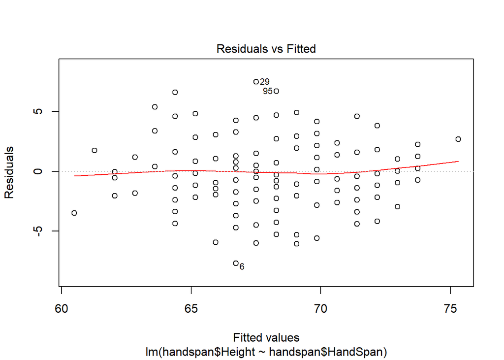

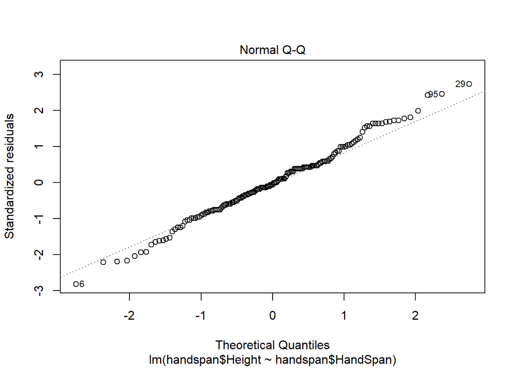

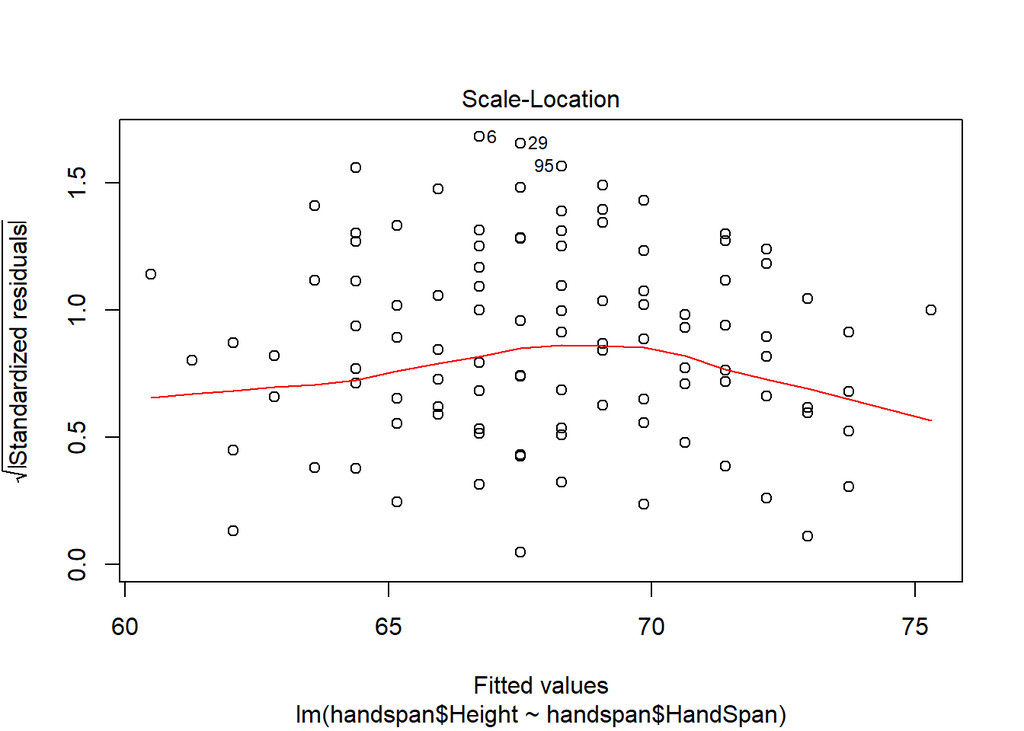

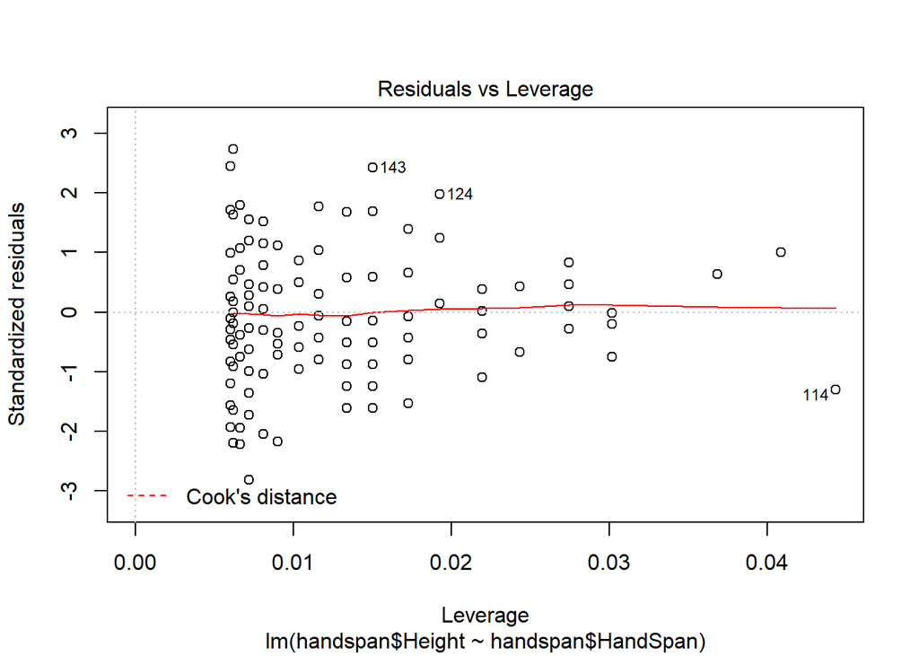

```r
plot(handspan.res)
```

적합된 모형의 잔차도를 확인해본 결과 잔차의 값이 큰 관측치가 몇 개 존재하기는 하지만 특별한 패턴이 관측되지는 않았다. 그리고 정규 분위수 그래프에서도 정규분포를 벗어난다 는 뚜렷한 증거는 발견되지 않았다. 따라서 주어진 자료에 대한 선형회귀모형의 적용은 타 당함을 알 수 있고, 적용된 모형을 통한 추론은 의미가 있다고 할 수 있다.

### 예제2. (carstopping.txt)

주어진 자료는 브레이크가 작동되는 순간의 자동차의 주행 속도 (Speed)에 따른 자동차 제동 거리(StopDist)를 조사한 자료이다.

1. 자동차의 주행 속도에 따른 자동차의 제동거리 간에는 서로 상관관계가 존재하는가? 상관 분석을 통해 이를 확인해보자.

```r
carstopping = read.table('carstopping.txt',header=TRUE)
cor.test(carstopping$StopDist, carstopping$Speed)
```

```
##
##  Pearson's product-moment correlation
##
## data:  carstopping$StopDist and carstopping$Speed
## t = 20.68, df = 61, p-value < 2.2e-16
## alternative hypothesis: true correlation is not equal to 0
## 95 percent confidence interval:
##  0.8952425 0.9606129
## sample estimates:
##       cor
## 0.9355037
```

상 관계수를 구해보면 0.9355037로 나타난다. 상관관계 유무의 검정 결과, 검정통계량은 20.68이고 유의확률은 매우 작은 것으로 확인되었다. 따라서 유의 수준 5%에서 두 변수 사이의 상관관계가 존재한다는 매우 뚜렷한 증거가 있다.

2. 주어진 자료에 단순 선형회귀모형을 적용한 후 결과를 확인해 보자. 유의수준 5%에서 모 형은 유의한가?

```r
carstopping.res = lm(carstopping$StopDist~ carstopping$Speed)
summary(carstopping.res)
```

```
##
## Call:
## lm(formula = carstopping$StopDist ~ carstopping$Speed)
##
## Residuals:
##     Min      1Q  Median      3Q     Max
## -25.141  -7.300  -2.141   6.044  35.946
##
## Coefficients:
##                   Estimate Std. Error t value Pr(>|t|)
## (Intercept)       -20.2734     3.2384   -6.26 4.25e-08 ***
## carstopping$Speed   3.1366     0.1517   20.68  < 2e-16 ***
## ---
## Signif. codes:  0 '***' 0.001 '**' 0.01 '*' 0.05 '.' 0.1 ' ' 1
##
## Residual standard error: 11.8 on 61 degrees of freedom
## Multiple R-squared:  0.8752, Adjusted R-squared:  0.8731
## F-statistic: 427.7 on 1 and 61 DF,  p-value: < 2.2e-16
```

3. 적합된 회귀 모형의 잔차도를 확인해 보자. 단순선형회귀모형의 적용이 타당하다고 볼 수 있는가?

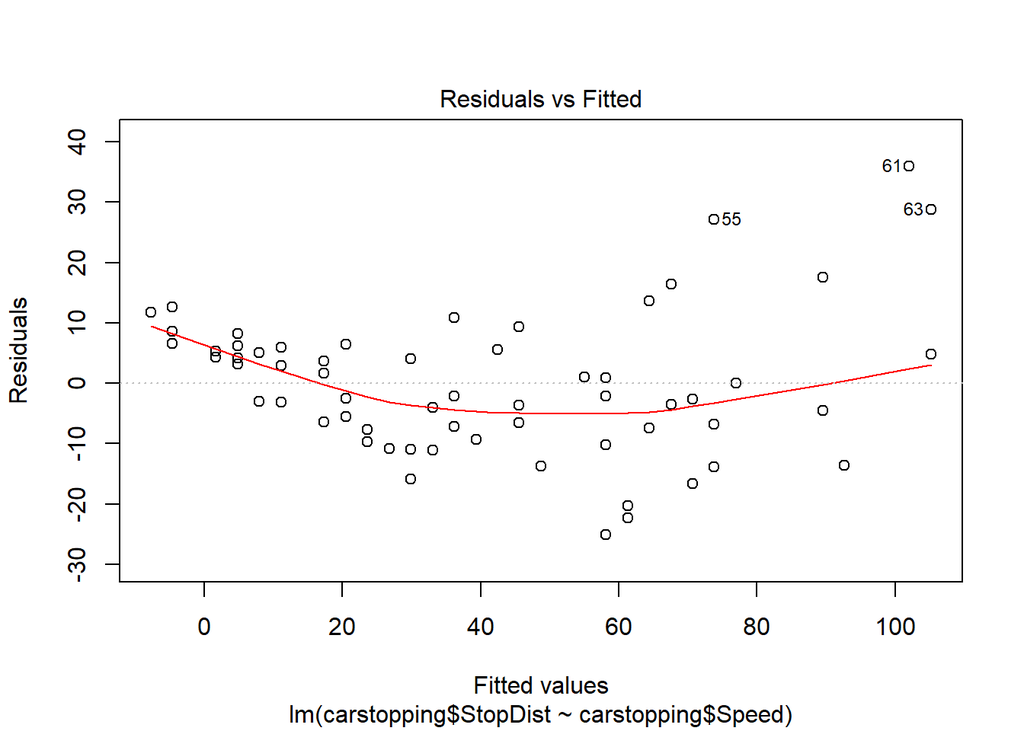

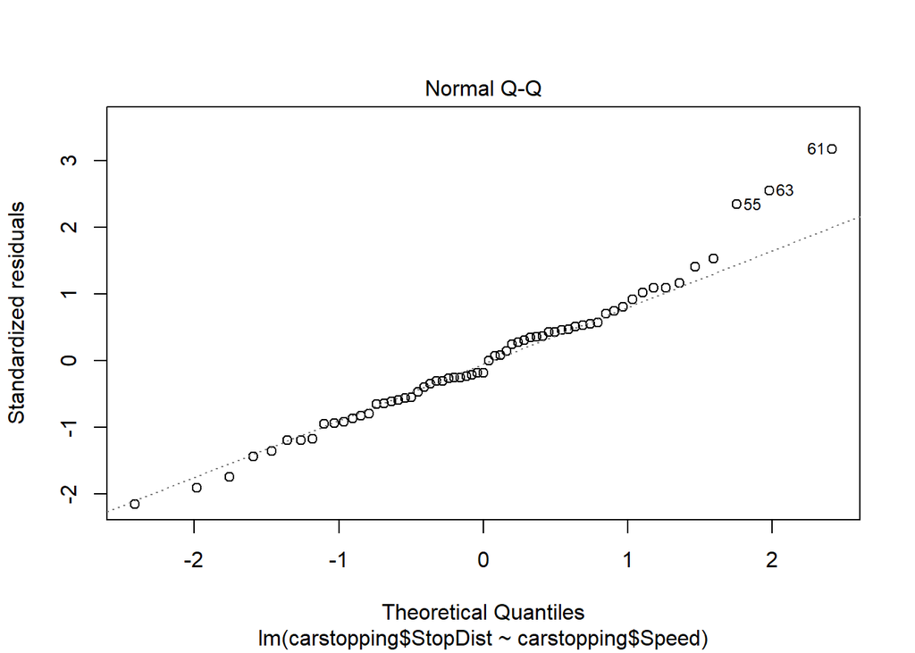

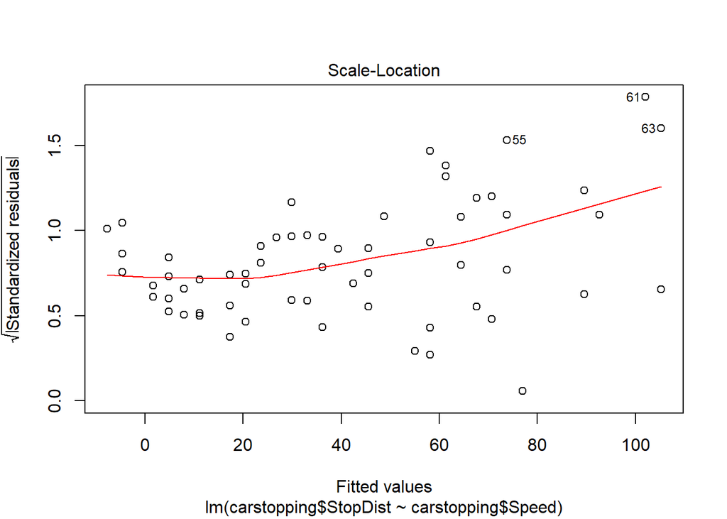

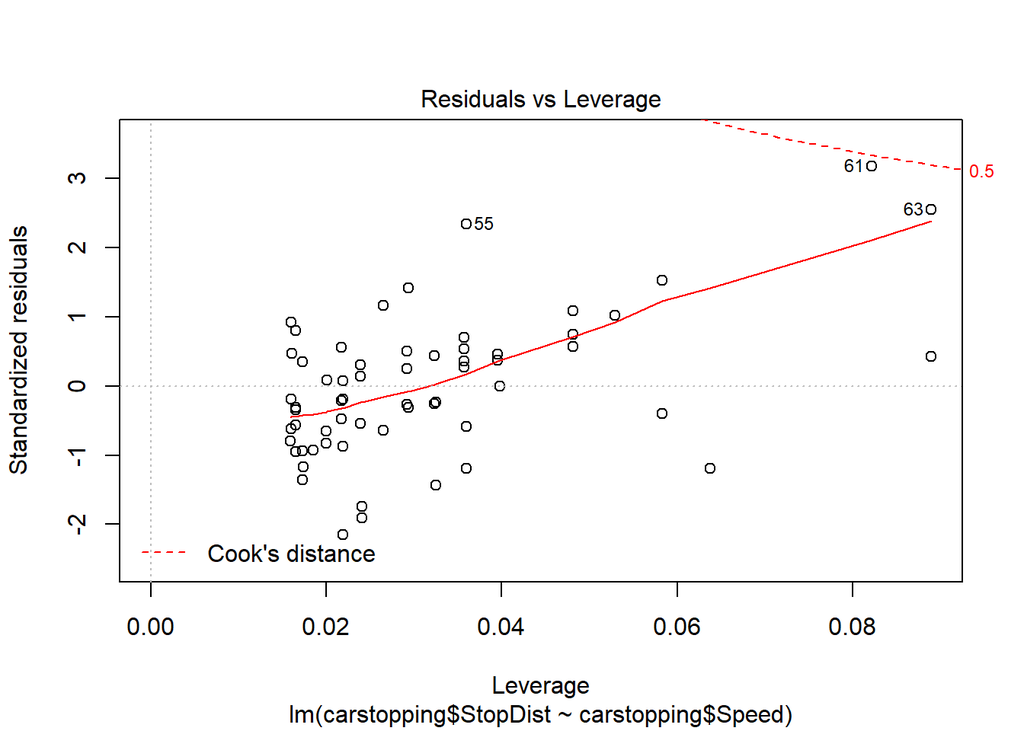

```r
plot(carstopping.res)
```

적합된 모형의 잔차도를 확인해본 결과 등분산성이 어긋나는 패턴이 관측되었다. 그리고 정규 분위수 그래프에서 양 끝쪽으로 직선에서 벗어난 점들이 관찰되지만 대부분의 잔차는 직선 주위에 몰려있는 것을 확인할 수 있다. 주어진 자료에 대한 선형회귀모형의 적용은 타당함을 않고, 적용된 모형을 통한 추론은 의미가 있다고 할 수 없다.

4. 자동차의 주행속도와 자동차의 제동거리 사이의 산점도를 확인해보자. 두 변수 사이에는 곡률(curvature)관계가 존재하며, 또한 x 값이 증가함에 따라 y값의 산포가 증가하는 것을 확 인할 수 있다. 따라서 주어진 자료에 대해서는 단순 선형회귀 모형의 적용이 적절하지 않다. 이러한 문제를 해결하기 위한 방법 중 하나는 반응변수에 적절한 함수 변환(transformation) 을 취하는 것이다. 즉, 반응변수에 제곱근을 취한 새로운 변수(sqrt.dist)를 만든 후, 새로운 변수 sqrt.dist와 주행속도(Speed)의 산점도를 다시 한번 그려보자. 새로운 산점도는 어떠한 형태를 보이고 있는가?

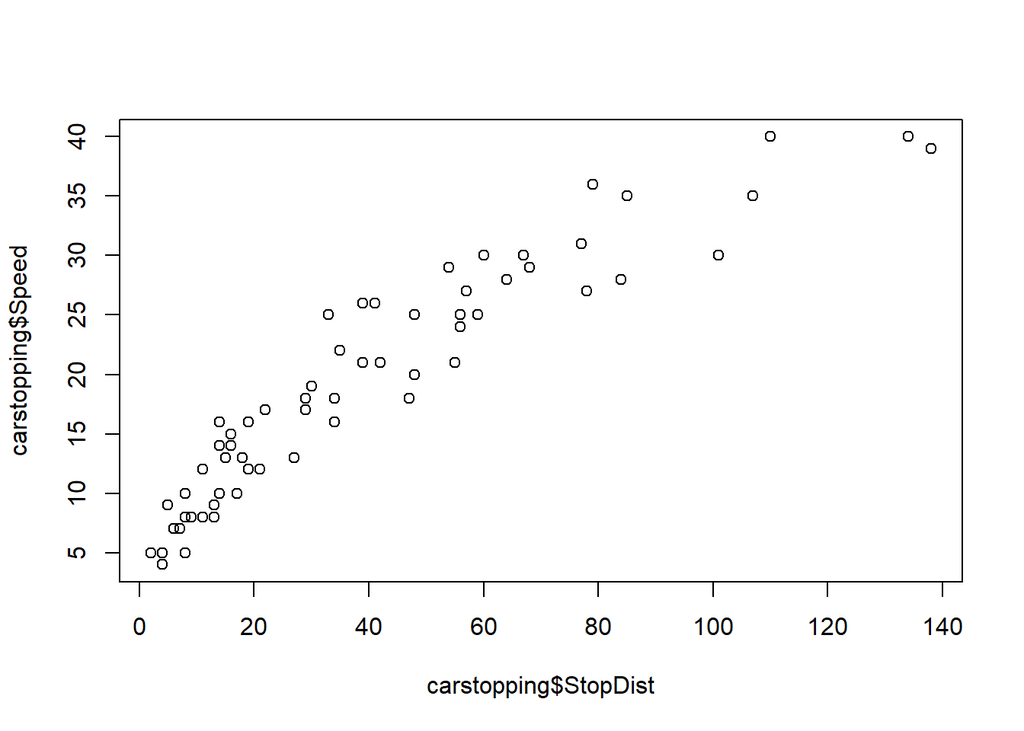

```r
plot(carstopping$StopDist, carstopping$Speed)
```

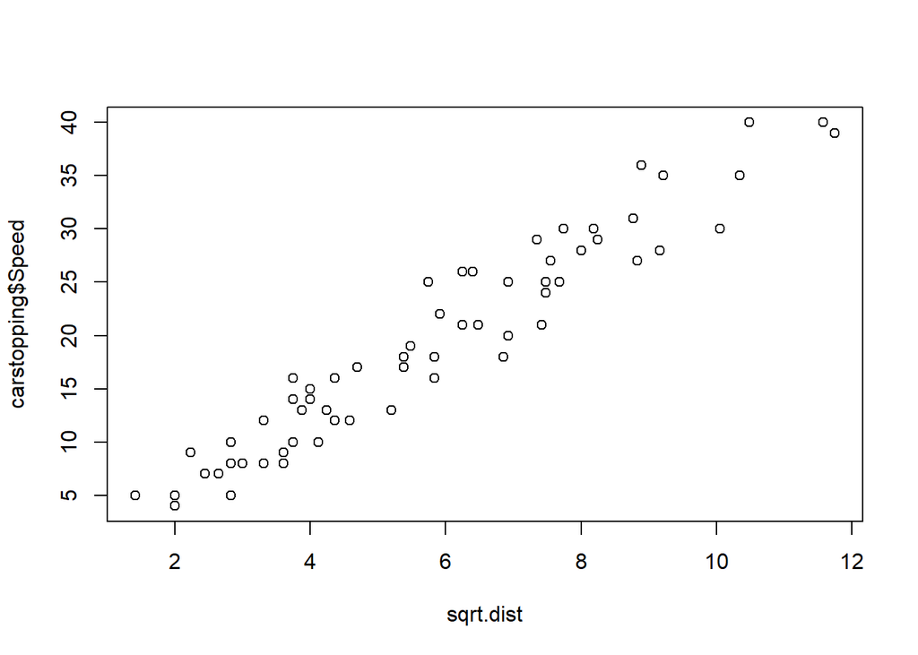

```r
sqrt.dist = sqrt(carstopping$StopDist) ; plot(sqrt.dist, carstopping$Speed)
```

5. 새로운 변수 sqrt.dist와 Speed에 대해 단순선형회귀모형을 적합 시킨 후 결과를 확인해 보자. 새로운 모형의 결정계수  값은 얼마인가? (1)번에서 구한 모형의 결정계수 값과 비교해보시오.

```r
carstopping2.res = lm(sqrt.dist ~ carstopping$Speed)
summary(carstopping2.res)
```

```
##
## Call:
## lm(formula = sqrt.dist ~ carstopping$Speed)
##
## Residuals:
##     Min      1Q  Median      3Q     Max
## -1.4879 -0.5487  0.0098  0.5291  1.5545
##
## Coefficients:
##                   Estimate Std. Error t value Pr(>|t|)
## (Intercept)       0.918283   0.197406   4.652 1.82e-05 ***
## carstopping$Speed 0.252568   0.009246  27.317  < 2e-16 ***
## ---
## Signif. codes:  0 '***' 0.001 '**' 0.01 '*' 0.05 '.' 0.1 ' ' 1
##
## Residual standard error: 0.7193 on 61 degrees of freedom
## Multiple R-squared:  0.9244, Adjusted R-squared:  0.9232
## F-statistic: 746.2 on 1 and 61 DF,  p-value: < 2.2e-16
```

회기 직선 : y hat(sqrt_StopDist) = 0.918283 + 0.252568(Speed)

1번에서 구한 모형의 결정계수 값 : 0.8752

5번에서 구한 모형의 결정계수 값 : 0.9244

1번에서 구한 모형의 결정계수 값보다 5번에서 구한 모형의 결정계수 값이 더 크게 나왔다.

6. 새로운 모형의 잔차도를 확인해보자. 단순선형회귀모형의 적용이 타당하다고 볼 수 있는 가?

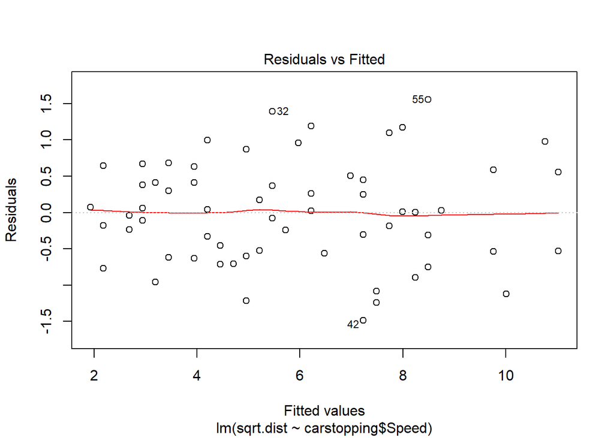

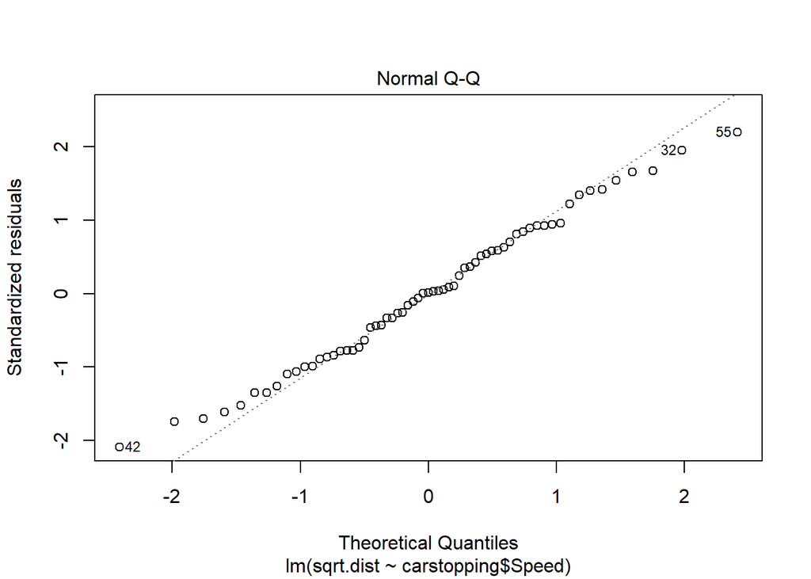

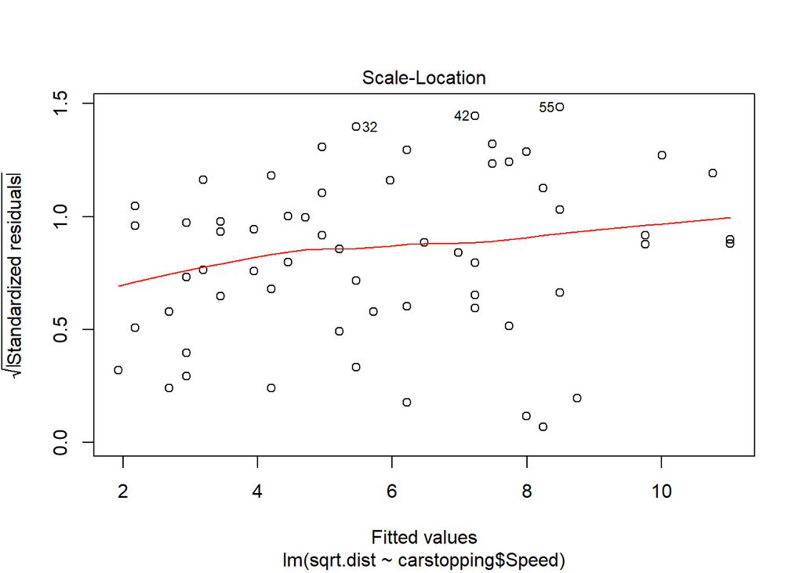

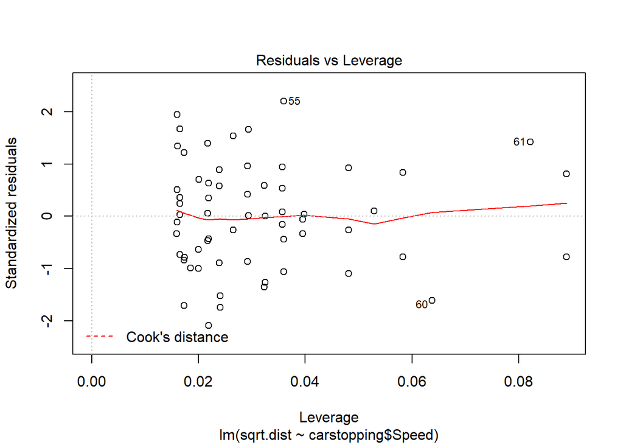

```r
plot(carstopping2.res)
```

적합된 모형의 잔차도를 확인해본 결과 특별한 패턴이 관측되지는 않았다. 그리고 정규 분위수 그래프에서도 정규분포를 벗어난다 는 뚜렷한 증거는 발견되지 않았다. 따라서 주어진 자료에 대한 선형회귀모형의 적용은 타 당함을 알 수 있고, 적용된 모형을 통한 추론은 의미가 있다고 할 수 있다.

### 예제3. (hospital.txt)

다음은 미국 내 113개의 병원들을 대상으로 입원 기간 동안 환자들이 받는 감염 위험과 관련된 사항들을 조사하였다. 다음은 주요 변수에 대한 설명이다. 변수명 설명 InfctRsk 종속변수. 감염 위험 정도 Stay 설명변수1. 환자들의 평균 입원 기간 Age 설명변수2. 환자들의 평균 나이 Xray 설명변수3. 해당 병원의 X-ray 검진 횟수

1. 종속변수와 각 설명변수들 간에는 유의한 상관관계가 존재하는가? 산점도와 상관분석을 통해 이를 확인해보시오.

```r
hospital <- read.table('hospital.txt',header=TRUE)
#hospital <- select(InfctRsk, Stay, Age, Xray)
#table(hospital$InfctRsk, hospital$Stay, hospital$Age, hospital$Xray)
hospital = hospital[,c(2,3,4,6)]
hospital
```

[output not shown]

[output cut: 99 more lines]

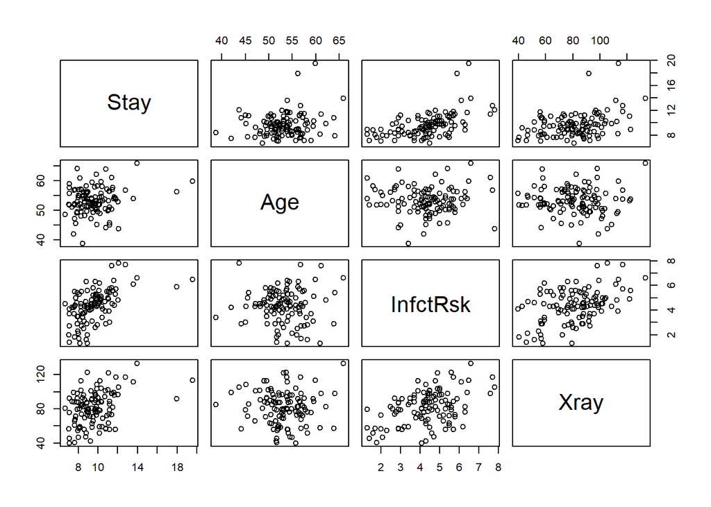

```r
plot(hospital)
```

```r
cor(hospital)
```

```
##               Stay          Age    InfctRsk       Xray
## Stay     1.0000000  0.188913972 0.533443831  0.3824819
## Age      0.1889140  1.000000000 0.001093166 -0.0188549
## InfctRsk 0.5334438  0.001093166 1.000000000  0.4533916
## Xray     0.3824819 -0.018854897 0.453391557  1.0000000
```

2. 주어진 자료에 다중선형회귀모형을 적용해보자. 유의수준 5%에서 모형은 유의하다고 할 수 있는가? 각 변수들은 유의한가?

```r
hospital.res = lm(hospital$InfctRsk ~ hospital$Stay + hospital$Age + hospital$Xray)
summary(hospital.res)
```

```
##
## Call:
## lm(formula = hospital$InfctRsk ~ hospital$Stay + hospital$Age +
##     hospital$Xray)
##
## Residuals:
##      Min       1Q   Median       3Q      Max
## -2.77320 -0.73779 -0.03345  0.73308  2.56331
##
## Coefficients:
##                Estimate Std. Error t value Pr(>|t|)
## (Intercept)    1.001162   1.314724   0.761 0.448003
## hospital$Stay  0.308181   0.059396   5.189 9.88e-07 ***
## hospital$Age  -0.023005   0.023516  -0.978 0.330098
## hospital$Xray  0.019661   0.005759   3.414 0.000899 ***
## ---
## Signif. codes:  0 '***' 0.001 '**' 0.01 '*' 0.05 '.' 0.1 ' ' 1
##
## Residual standard error: 1.085 on 109 degrees of freedom
## Multiple R-squared:  0.363,  Adjusted R-squared:  0.3455
## F-statistic:  20.7 on 3 and 109 DF,  p-value: 1.087e-10
```

회기 직선 : y hat(InfctRsk) = 1.001162 + 0.308181(Stay) -0.0230051(Age) + 0.019661(Xray)

모형의 유의성 검정 결과, 검정 통계량은 20.7이고 유의확률은 매우 작은 것으로 나타났다. 따라서 유 의수준 5%에서 모회귀함수는 유의하다고 할 수 있다.

각 계수별 유의성의 검정 결과, Stay와 Xray 계수의 유의확률이 유의수 준 5%보다 작게 나타났다. 따라서 Stay와 Xray는 InfctRsk를 설명함에 있어서 유의한 변수라고 볼 수 있다.

3. 다중선형회귀모형의 적용은 타당하다고 볼 수 있는가?

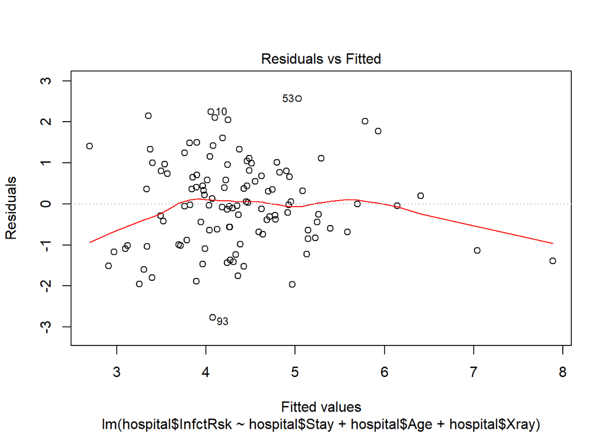

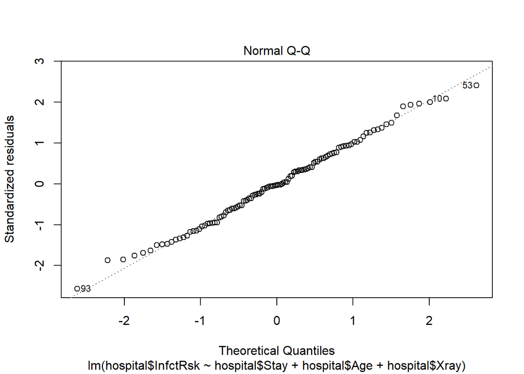

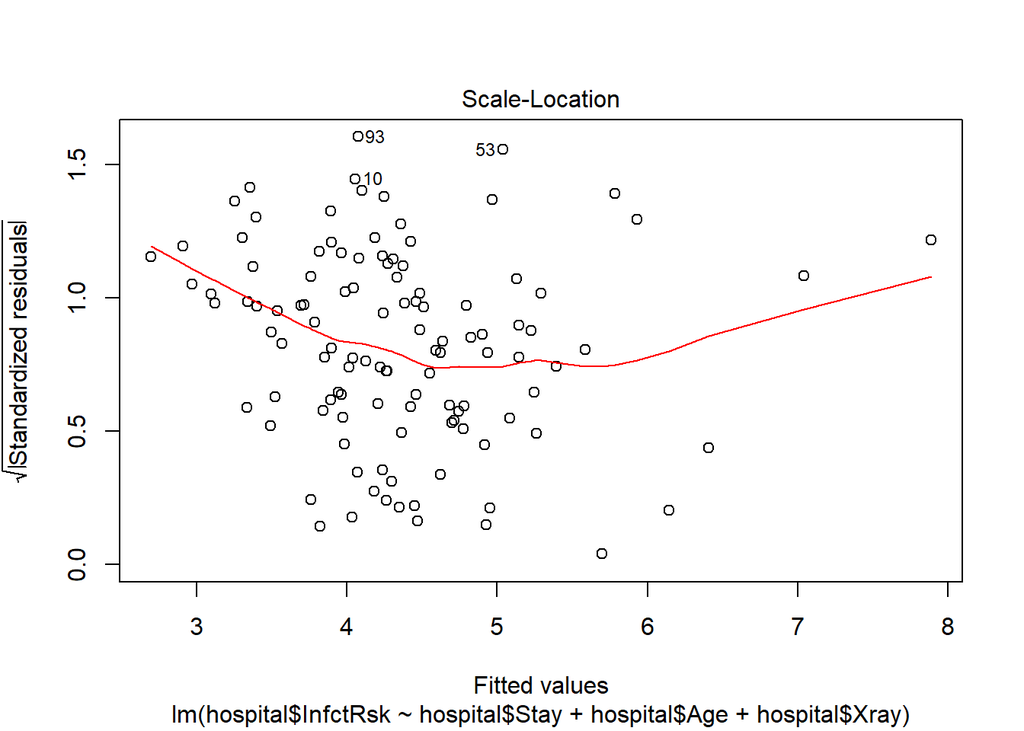

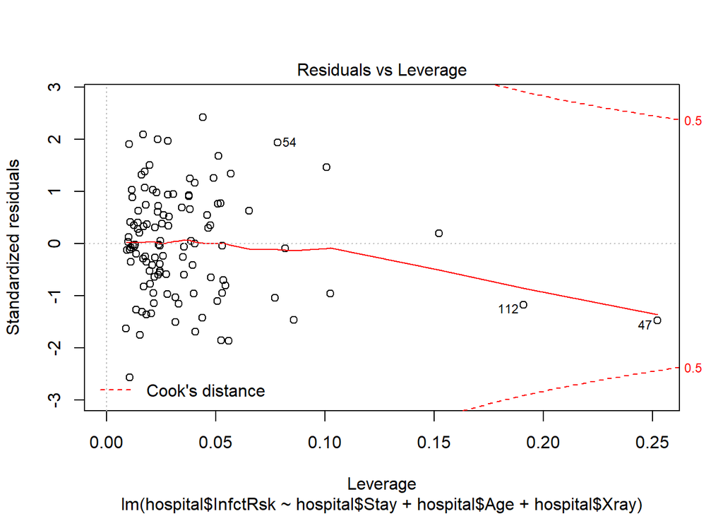

```r
plot(hospital.res)
```

결정계수의 값은 0.363 (수정된 결정 계수는 0.3455)로 나타났고 따라서 자료 전체의 산포 중 약 36%가 모회귀함수에 의해서 설명됨을 알 수 있다.

적합된 모형의 잔차도를 확인해본 결과 특별한 패턴이 관측되지는 않았다. 그리고 정규 분위수 그래프에서도 정규분포를 벗어난다 는 뚜렷한 증거는 발견되지 않았다. 따라서 주어진 자료에 대한 중선형회귀모형의 적용은 타 당함을 알 수 있고, 적용된 모형을 통한 추론은 의미가 있다고 할 수 있다.